# R Markdown Tutorial

This is an introduction to data visualization (in R).

We will be using `ggplot2` to plot our data. Let’s make sure you have that installed.

We will use the data from the Baker 2016 paper, again.

```r
# Load in our data:
baker2016 = read.csv('baker_2016_edited.txt',sep = "\t")
```

| job | familiar_reproducibility | significance_crisis | proportion_reproducible |
| --- | --- | --- | --- |
| Research Scientist | Fairly familiar | There is a slight crisis of reproducibility | 90% |
| Student | Very familiar | There is a slight crisis of reproducibility | 40% |
| Associate professor/Lecturer | Very familiar | There is a significant crisis of reproducibility | 30% |
| Principal Investigator | Very familiar | There is a significant crisis of reproducibility | 50% |
| PhD Student | Fairly familiar | There is a slight crisis of reproducibility | 70% |
| PhD Student | Very familiar | There is a significant crisis of reproducibility | 20% |

The basic structure of a gpplot looks as follows. You call `ggplot`, pass over some `data`, specify aesthetics using `aes()` and detmine the geometry using one (or several) of the following (or many more) options:

- `geom_point()`
- `geom_bar()`
- `geom_boxplot()`
- `geom_col()`
- `geom_hist()`
- `geom_density()`

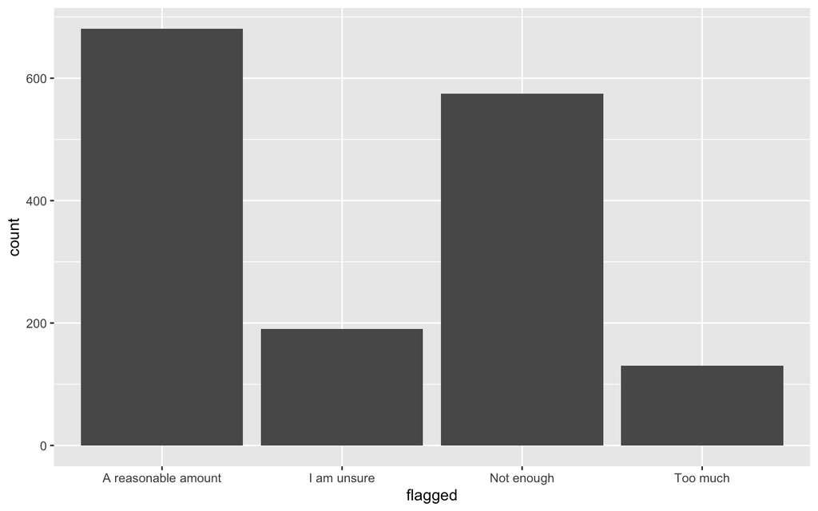

```r
ggplot(baker2016, aes(x= flagged)) +
  geom_bar()
```

# What is your message?

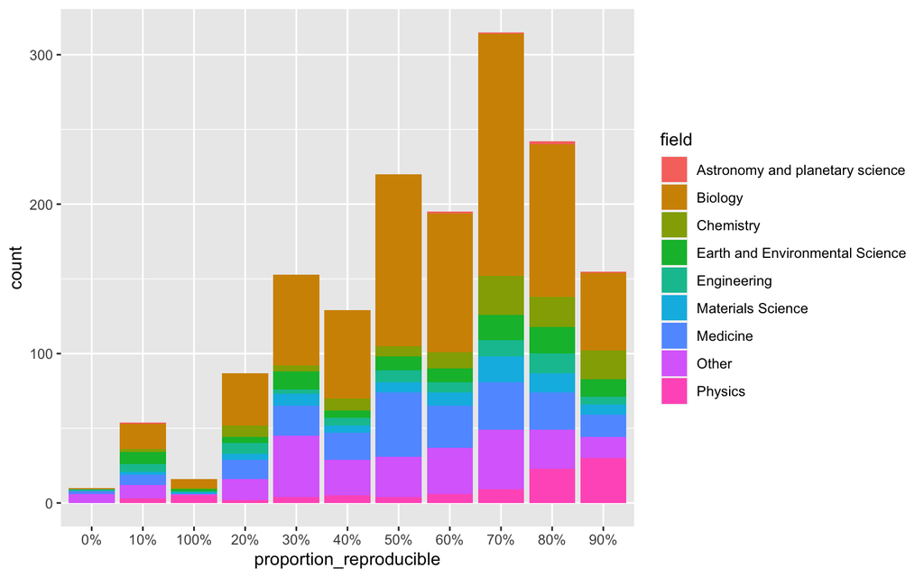

```r
ggplot(baker2016, aes(group= field, fill=field, x = proportion_reproducible)) +
  geom_histogram(stat='count')
```

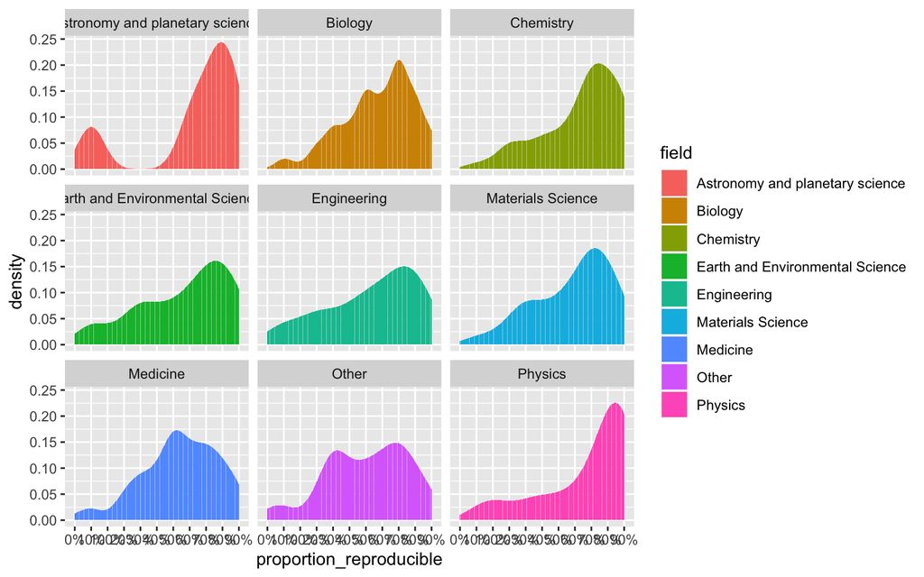

```r
ggplot(baker2016, aes(group= field, fill=field, x = proportion_reproducible)) +
  geom_histogram(stat = 'density') +
  facet_wrap(facets = baker2016$field)
```

# Statistics in figures - or how not to fool your audience (and yourself)

Here, I am creating an artificial dataset to illustrate some points on how (not to) plot your data.

```r
response1 = rnorm(n = 1000, mean = 10, sd = c(1,2))
response2 = rnorm(n = 1000, mean = c(2,3), sd = 1)
response3 = rnorm(n = 1000, mean = c(4,5), sd = c(1,1.5))
group = rep(letters[1:2], length.out = 100)
df = data.frame(group = as.factor(group), response1=response1, response2=response2, response3=response3)
```

You may think it’s a good idea to first plot this data as a barplot, displaying the mean value for `response1` in groups `a` and `b`. This is what such a plot would look like:

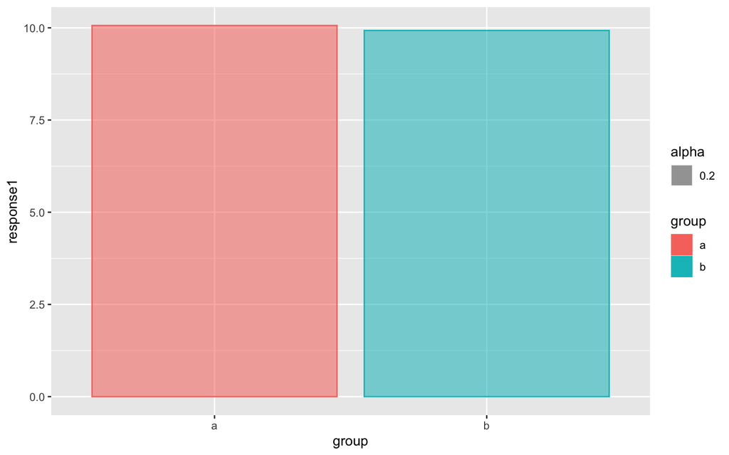

```r
ggplot(df, aes(x=group,y=response1, color=group, fill=group, alpha=0.2)) +
  geom_bar(stat='summary', fun=mean)
```

Now you may have noticed that when I created the data, I intentionally created both groups to have the same mean value. However, their standard deviations are very different!

The following plots display the exact same data - but now in a more useful format.

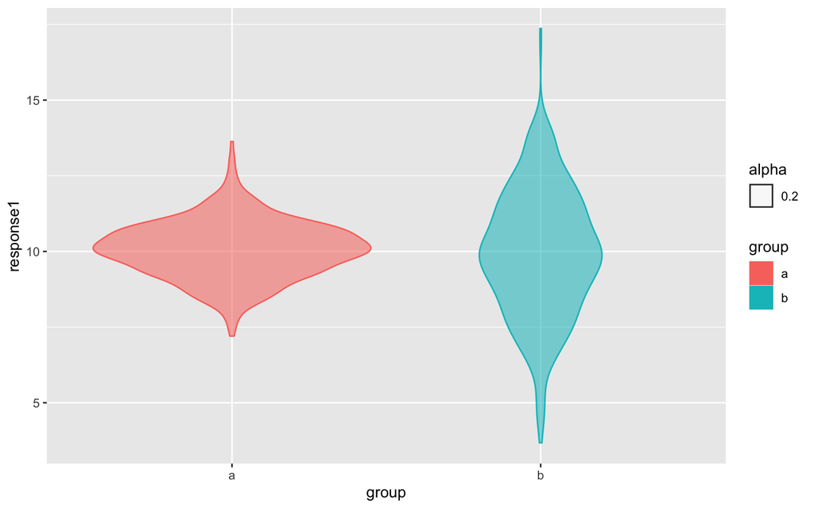

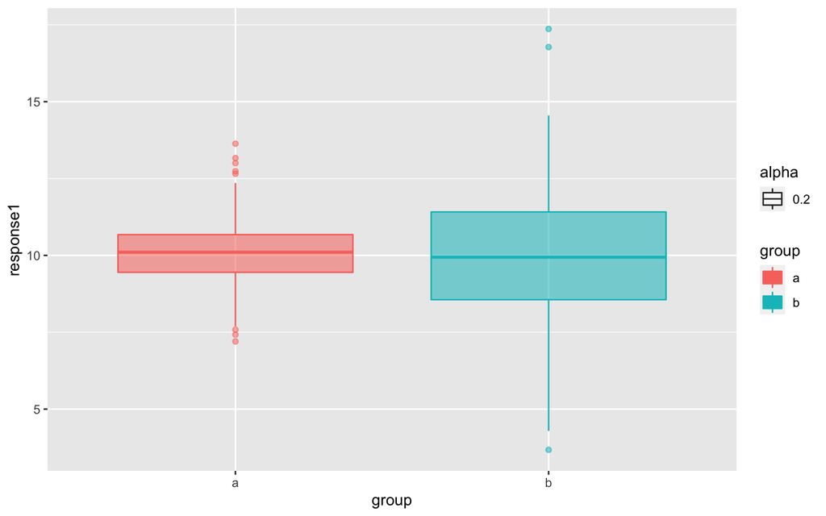

```r
par(mfrow=c(2,1))
ggplot(df, aes(x=group,y=response1, color=group, fill=group, alpha=0.2)) +
  geom_violin()

ggplot(df, aes(x=group,y=response1, color=group, fill=group, alpha=0.2)) +
  geom_boxplot()
```

# Wide and Long Format

The data as it is right now is in the so-called *wide format*. For many types of plots that maynot be useful.

```r
library(tidyr)

# Get data from wide into long format
data_wide = baker2016[,c(20,21,27)]
data_long = gather(data_wide, question, response, 1:2)

# Delete responses where participants couldn't remember the result
data_long = data_long[-which((data_long$response == "I can't remember")),]
```

Plot data

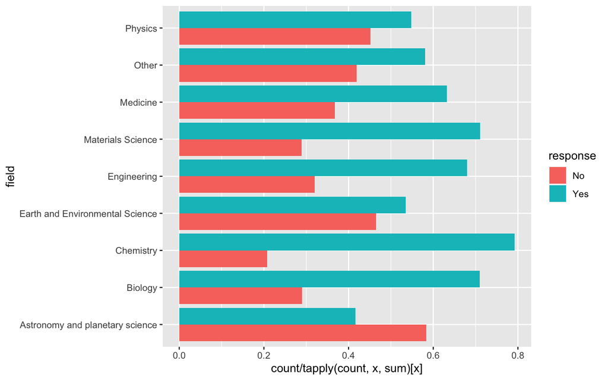

```r
ggplot(data_long, aes(x = field, fill=response)) +
  #geom_bar(stat='count',position = "dodge")+
  geom_bar(aes(y = ..count../tapply(..count.., ..x.. ,sum)[..x..]), position = 'dodge',group = 1) +
  coord_flip()
```

# Prettier Plots

You can change a whole range of aspects about a theme. A comprehensive list of options can be found [here](https://ggplot2.tidyverse.org/reference/theme.html). Here are a few basic things to get started with:

## Axis labels

Add a title using `ggtitle('Your title goes here.')` and change the axis lables using `xlab('X axis title')` and `ylab('X axis title')`.

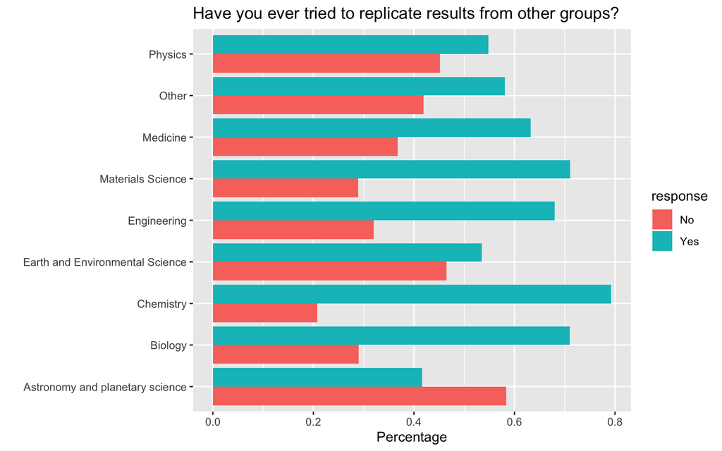

```r
ggplot(data_long, aes(x = field, fill=response)) +
  geom_bar(aes(y = ..count../tapply(..count.., ..x.. ,sum)[..x..]), position = 'dodge',group = 1) +
  ylab('Percentage')+
  xlab('')+
  ggtitle('Have you ever tried to replicate results from other groups?')+
  coord_flip()
```

## Change the theme:

Ggplot has built in [themes](https://ggplot2.tidyverse.org/reference/ggtheme.html) that you can make use of. These include: `theme_bw()`, `theme_classic()`, and `theme_void()`. Try out a few and see the effects on this plot:

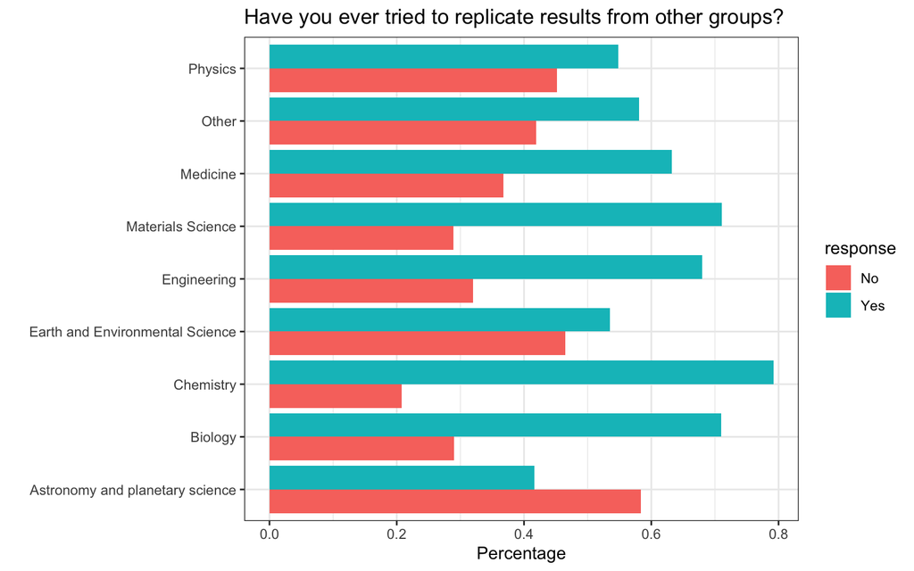

```r
ggplot(data_long, aes(x = field, fill=response)) +
  geom_bar(aes(y = ..count../tapply(..count.., ..x.. ,sum)[..x..]), position = 'dodge',group = 1) +
  ylab('Percentage')+
  xlab('')+
  ggtitle('Have you ever tried to replicate results from other groups?')+
  coord_flip()+
  theme_bw()
```

## Edit legend

By default, ggplot uses the factor names from your data in the legend, and the respective variable name as the title.

There are a variety of ways you can edit the legend. Here, we will use `labs()`.

Since our legend refers to the fill color of the plot, you will have to reference *fill* when editing it. You may not want to have a legent title at all, in which case you could add: `labs(fill='')`. Or maybe you would like to rename it to *Questionnaire Response* using `labs(fill='Questionnaire Response')`?

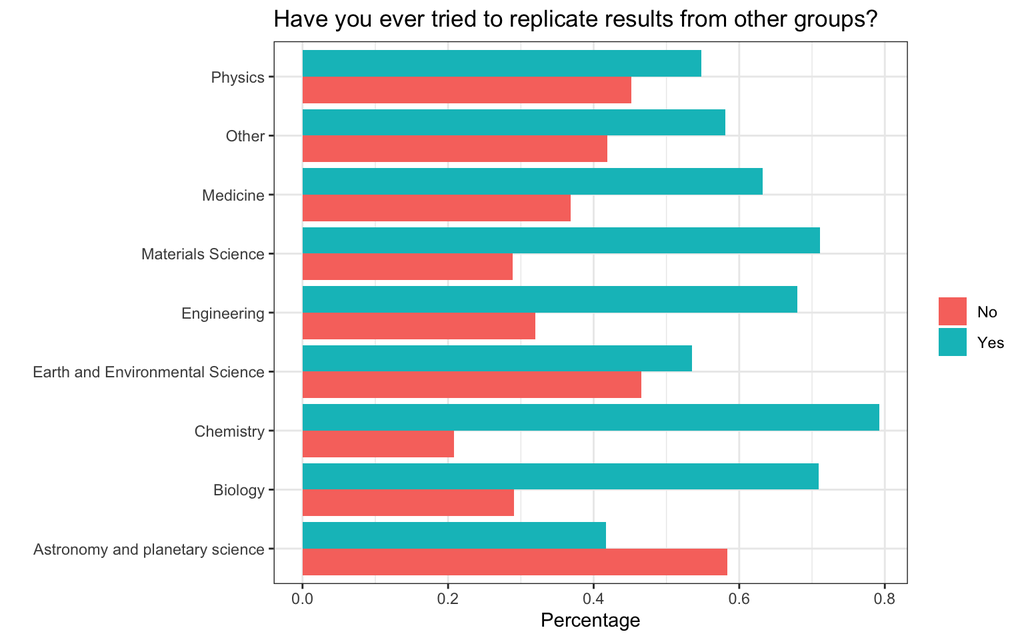

```r
ggplot(data_long, aes(x = field, fill=response)) +
  geom_bar(aes(y = ..count../tapply(..count.., ..x.. ,sum)[..x..]), position = 'dodge',group = 1) +
  ylab('Percentage')+
  xlab('')+
  ggtitle('Have you ever tried to replicate results from other groups?')+
  coord_flip()+
  theme_bw() +
  labs(fill='')
```